# act_report

## WeRateDogs THREE Insights in full

Data gotten from the real-world data is rarely clean. Using python and its libraries, we have gathered over 5000 tweet data as they stood on 1st of August 2017 of Twitter user [@dog_rates](https://twitter.com/dog_rates), also known as **WeRateDogs**, from various sources and in various formats, assessed its quality and tidiness and cleaned it.

**WeRateDogs** is a Twitter account with over 4 million followers that rates people's dogs. These ratings almost always have a denominator of 10 albeit the numerators, almost always greater than 10 i.e. 11/10, 12/10, 13/10, etc.

Herein we discuss the observation from three important insights about the **WeRateDogs** data before the **1st of August 2017.**

## Which dog breed is the most liked and how it compares in terms of retweet?

With over 50 different dog breeds in the WeRateDogs data and the plot below shows the number of times each dog breed was liked and retweeted the given timeframe.

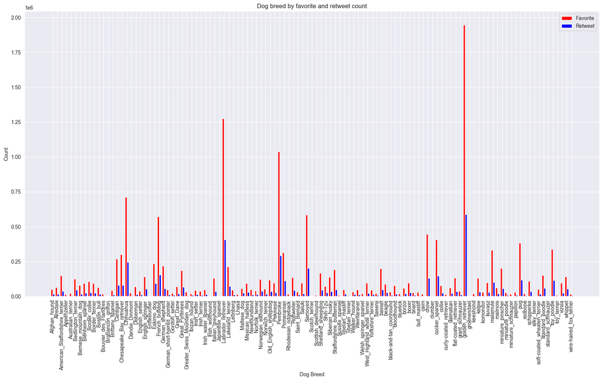

Also, it's clear that dog specie with higher favorite counts tend to have more retweet count.

## Which dog stage has the highest average rating?

According to [Dogtionary](https://www.amazon.com/Dogtionary-Meaningful-Portraits-Sharon-Montrose/dp/0670034991), there are several stages of dog. However, because of the scope of the project we focused on just four dog stages i.e. Doggo, Floofer, Puppo and Pupper. The plot below shows the diffence in average numerator ratings of each dog stage.

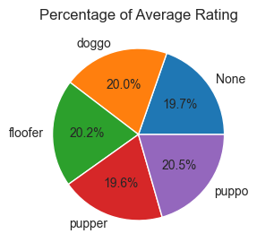

The pie chart above clearly shows that less than one-quarter of each dog stage average rating is greater than the total mean. Although, the **puppo** dog stage is marginally higher than **floofer, doggo and pupper**, with 20.2%, 20.0% and 19.6 % respectively.

It also shows that more than 19% of the average rating greater than the total mean is neither **puppo, floofer,doggo nor pupper**.

## Which dog stage is most liked and how it compares in terms of retweet?

The variant plots below represensts each dog stage by retweet and favorite count.

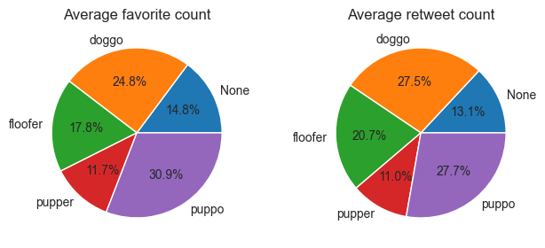

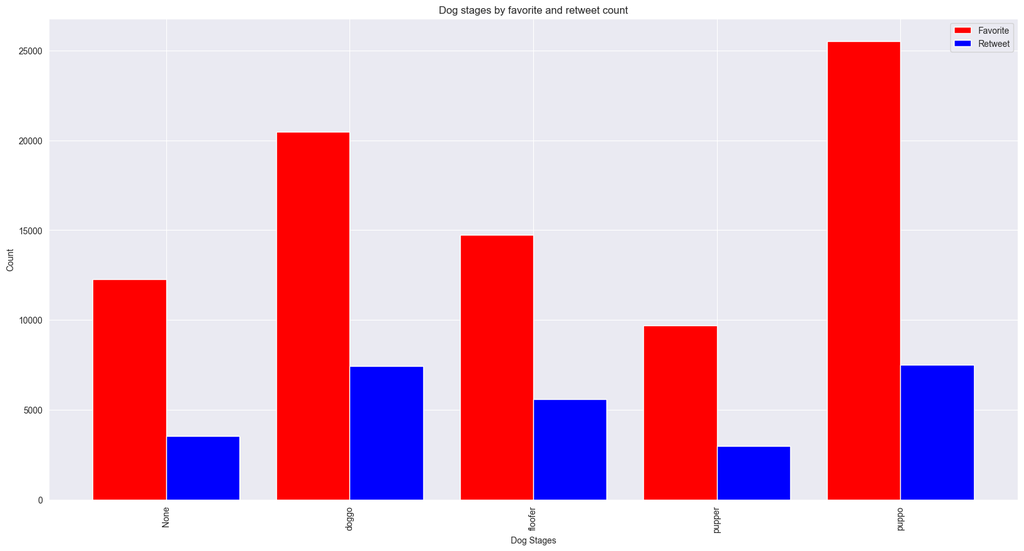

The charts above displays the dog stage average count by the Favorite and retweet column. From the pie chart, it's easier to observe that the favorite column has relatively more pupper and puppo category, and fewer floofer and doggo than the retweet column. The two columns are marginally different for the category thats neither **puppo, floofer,doggo nor pupper**.